# Drivers of Mourning Cloak Population

# Packages

```r
library(pls)
library(tidyverse)
library(here)
```

# Read and clean up data

| year | MOCL | WiTemp | SprTemp | SuTemp | FaTemp_prev | JanPDSI | FebPDSI | MarPDSI | AprPDSI | MayPDSI | JunPDSI | JulPDSI | AugPDSI | SepPDSI | OctPDSI | NovPDSI | DecPDSI | WiPDSI | SprPDSI | SuPDSI | FaPDSI | MOCL_fall |
| --- | --- | --- | --- | --- | --- | --- | --- | --- | --- | --- | --- | --- | --- | --- | --- | --- | --- | --- | --- | --- | --- | --- |
| 2006 | 0.25479882 | 32.2 | 56.7 | 67.3 | 40.8 | 3.57 | 2.83 | 1.30 | 0.65 | 2.19 | 4.01 | 3.49 | 3.35 | 2.73 | 3.54 | 3.52 | 3.20 | 2.566667 | 2.2833333 | 3.1900000 | 3.420000 | 0.18368758 |
| 2007 | 0.13362796 | 28.8 | 55.8 | 67.6 | 44.3 | 1.98 | 1.28 | 1.66 | 3.04 | -0.29 | -0.52 | -0.07 | -0.94 | -1.47 | 3.25 | 3.30 | 2.34 | 1.640000 | 0.7433333 | -0.8266667 | 2.963333 | 0.05986544 |
| 2008 | 0.15981860 | 30.5 | 56.5 | 67.3 | 41.0 | 0.00 | 2.40 | 2.78 | 2.35 | 1.63 | 1.60 | 2.71 | 2.67 | 3.94 | -1.72 | -1.94 | 0.46 | 1.726667 | 1.8600000 | 3.1066667 | -1.066667 | 0.12093578 |
| 2009 | 0.17366952 | 27.9 | 56.0 | 66.1 | 40.1 | 3.62 | 2.59 | 1.98 | 1.72 | 1.51 | 2.13 | 4.12 | 4.15 | 3.38 | 3.52 | 3.13 | 3.99 | 2.730000 | 1.7866667 | 3.8833333 | 3.546667 | 0.08923675 |
| 2010 | 0.09454766 | 32.2 | 59.5 | 69.6 | 40.9 | 2.88 | 3.14 | 5.07 | -1.20 | -1.61 | -1.78 | -2.17 | -2.23 | -2.72 | 4.08 | 3.28 | 3.34 | 3.696667 | -1.5300000 | -2.3733333 | 3.566667 | 0.04858311 |
| NA | NA | NA | NA | NA | NA | NA | NA | NA | NA | NA | NA | NA | NA | NA | NA | NA | NA | NA | NA | NA | NA | NA |

- `year`: Year
- `MOCL`: Relative abundance of mourning cloak butterflies (*relative to what?*)
- `WiTemp`: Winter temperature average
- `SprTemp`: Spring temperature average
- `SuTemp`: Summer temperature average
- `FaTemp_prev`: The temperature of the previous fall
- `*PDSI`: Palmer drought severity index
- `MOCL_fall`: mourning cloak sightings after June 30 (see note below)

*Elizabeth’s note:*

> I added a response variable of mourning cloak sightings after June 30 because they fly as adults in spring then lay eggs and the 2nd gen flys in fall. Could also play around with timing of these responses - I thought fall adults would work well because summer drought was a weak predictor of total sightings

## Remove trailing row of NAs

```r
dat2 <- dat2 %>% filter(!is.na(year))
```

# Fit PLSR

```r
summary(m0)
```

```
Data:   X dimension: 20 8
    Y dimension: 20 1
Fit method: kernelpls
Number of components considered: 8

VALIDATION: RMSEP
Cross-validated using 10 random segments.
       (Intercept)  1 comps  2 comps  3 comps  4 comps  5 comps  6 comps  7 comps  8 comps
CV         0.05513  0.05363  0.05186  0.05269  0.05631  0.05676  0.05944  0.06110  0.06093
adjCV      0.05513  0.05296  0.05130  0.05190  0.05522  0.05564  0.05815  0.05966  0.05951

TRAINING: % variance explained
           1 comps  2 comps  3 comps  4 comps  5 comps  6 comps  7 comps  8 comps
X            26.97    55.85    64.93    76.32    84.51    91.46    97.80   100.00
MOCL_fall    35.13    43.95    50.39    52.52    54.49    55.52    55.78    55.83
```

```r
loadings(m0)
```

```
Loadings:
            Comp 1 Comp 2 Comp 3 Comp 4 Comp 5 Comp 6 Comp 7 Comp 8
WiTemp      -0.281  0.960 -0.374  0.408 -0.540  0.105
SprTemp     -0.210        -0.231  0.677 -0.101  0.261 -0.672  0.586
SuTemp      -0.360 -0.111 -0.247        -0.624  0.500         0.254
FaTemp_prev -0.378  0.350 -0.812         0.673 -0.277  0.176 -0.203
WiPDSI       0.184 -0.264 -0.244  0.659 -0.516  0.442 -0.197 -0.686
SprPDSI      0.485        -0.167        -0.161  0.508  0.266  0.130
SuPDSI       0.749        -0.475 -0.193  0.125        -0.375  0.201
FaPDSI       0.242 -0.285 -0.281  0.817 -0.262 -0.654  0.572  0.138

               Comp 1 Comp 2 Comp 3 Comp 4 Comp 5 Comp 6 Comp 7 Comp 8
SS loadings     1.284  1.214  1.305  1.777  1.521  1.288  1.069  1.000
Proportion Var  0.161  0.152  0.163  0.222  0.190  0.161  0.134  0.125
Cumulative Var  0.161  0.312  0.475  0.698  0.888  1.049  1.182  1.307
```

The first axis is cool, wet years, especially in the summer/spring when they are caterpillars/adults (overwinter as adults)

Test for model significance by selecting the number of components that significantly reduces prediction error (RMSEP) compared to the global RMSEP.

```
[1] 0
```

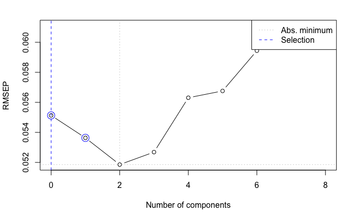

```r
selectNcomp(m0, alpha = 0.05, plot = TRUE) #NS by prediction error
```

Recomends 0 components

```r
m0a = lm(dat2$MOCL_fall[1:20] ~ m0$scores[,1] + m0$scores[,2])
summary(m0a)
```

```
Call:
lm(formula = dat2$MOCL_fall[1:20] ~ m0$scores[, 1] + m0$scores[,
    2])

Residuals:
      Min        1Q    Median        3Q       Max
-0.060701 -0.029026 -0.004817  0.021567  0.084775

Coefficients:
               Estimate Std. Error t value Pr(>|t|)
(Intercept)    0.111001   0.009510  11.672 1.54e-09 ***
m0$scores[, 1] 0.013304   0.004076   3.264  0.00457 **
m0$scores[, 2] 0.006258   0.003828   1.635  0.12049
---
Signif. codes:  0 ‘***’ 0.001 ‘**’ 0.01 ‘*’ 0.05 ‘.’ 0.1 ‘ ’ 1

Residual standard error: 0.04253 on 17 degrees of freedom
Multiple R-squared:  0.4395,    Adjusted R-squared:  0.3735
F-statistic: 6.664 on 2 and 17 DF,  p-value: 0.007298
```

# Try with ropls package

```
PLS
20 samples x 8 variables and 1 response
standard scaling of predictors and response(s)
```

|  | R2X(cum) | R2Y(cum) | Q2(cum) | RMSEE | pre | ort | pR2Y | pQ2 |
| --- | --- | --- | --- | --- | --- | --- | --- | --- |
| Total | 0.312 | 0.361 | 0.0808 | 0.0441 | 1 | 0 | 0.235 | 0.175 |

```
Single component model: only 'overview' and 'permutation' (in case of single response (O)PLS(-DA)) plots available
```

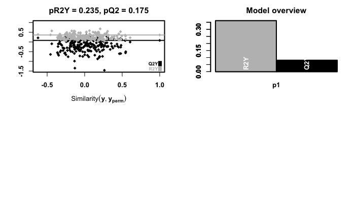

```r
m0.ropls <- opls(select(dat2, WiTemp, SprTemp, SuTemp, FaTemp_prev, WiPDSI, SprPDSI, SuPDSI, FaPDSI), dat2$MOCL_fall,
                 permI = 200)
```

```r
get_loadings(m0.ropls)
```

[output not shown]

Recommends 1 component, Q2 is very very low.

```r
get_VIP(m0.ropls) %>%
  arrange(desc(VIP))
```

[output not shown]